# Forecast For Time Series Forex Data By Statistical Methods

アセット･マネジメント･コンサルティング株式会社 http://am-consulting.co.jp

2016-12-16 14:43:17

- アセット･マネジメント･コンサルティング株式会社 http://am-consulting.co.jp
- SaECaNet http://saecanet.com/
- Olive http://olive.saecanet.com/
- twitter https://twitter.com/AMC2_Japan

本ページへのリンクを共有:[Tweet](https://twitter.com/share)

```
## Title       :  Forecast for JPY,EUR,GBP and ZAR : Monthly - 2016-12
## Data Source :  Federal Reserve Bank of St. Louis
## Author      :  アセット･マネジメント･コンサルティング株式会社 http://am-consulting.co.jp
```

#### Caution

- Financial transactions and future forecasts based on the data of this page are absolutely prohibited.
- 本ページのデータを根拠にした金融取引、将来予測は絶対禁止とします。

## Japan / U.S. Foreign Exchange Rate

#### Period:2007-01 ~ 2016-12

##### *“Averages of daily figures. Noon buying rates in New York City for cable transfers payable in foreign currencies.”(Source:FRED)*

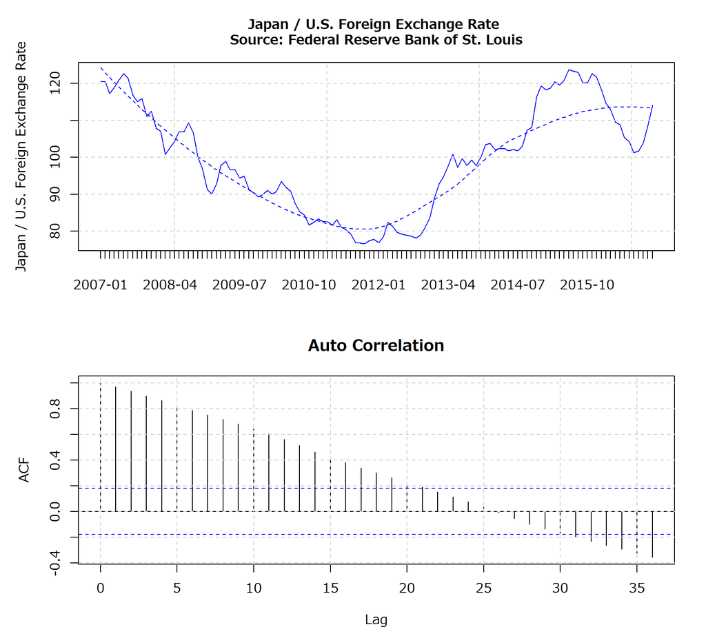

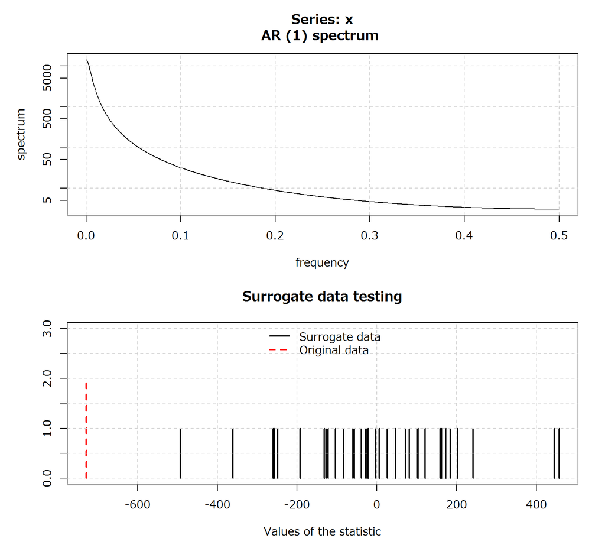

|  | Unit Root Test |
| --- | --- |
| statistic | -2.114028 |
| parameter | 4 |
| alternative | stationary |
| p.value | 0.5292136 |
| method | Augmented Dickey-Fuller Test |
| data.name | Japan / U.S. Foreign Exchange Rate |

##### Surrogate Test. Null Hypothesis: Data comes from a linear stochastic process K=1, significance=0.05

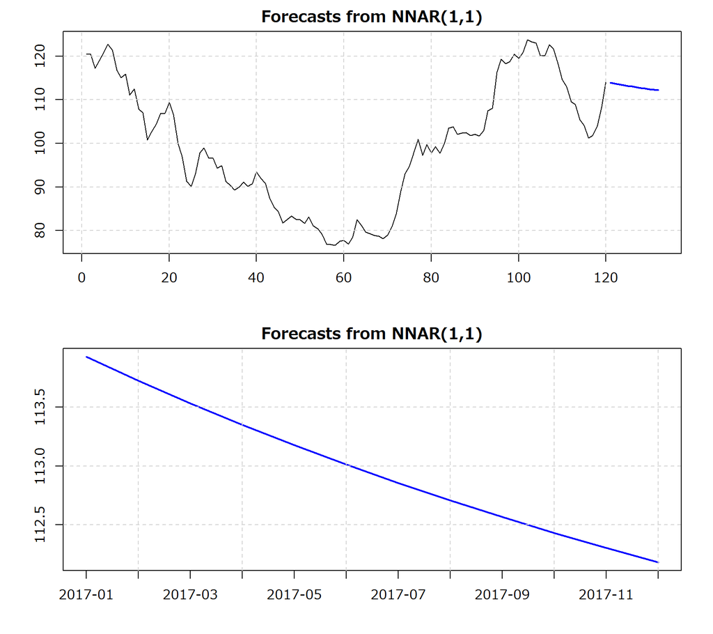

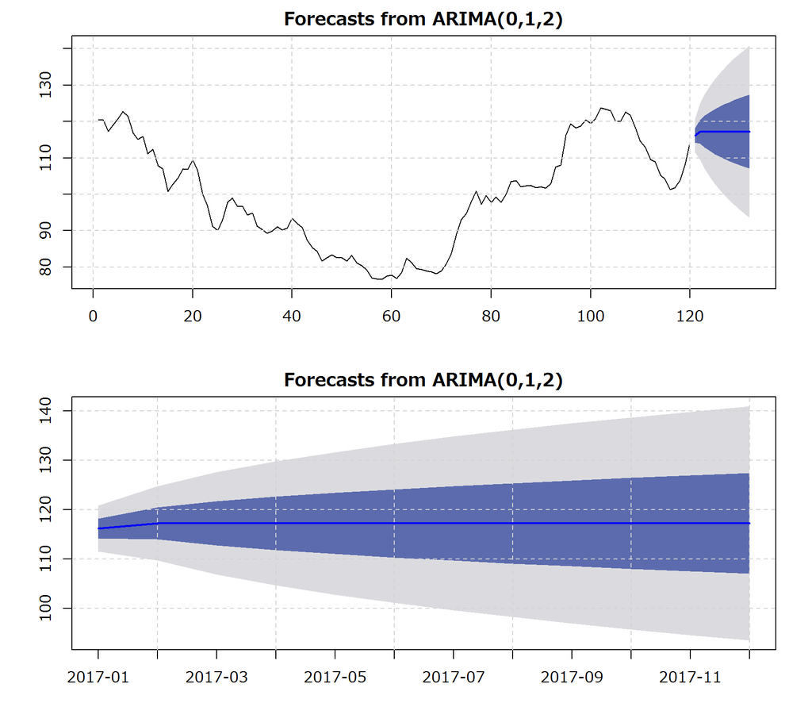

##### *C.I(%) = 60,95*

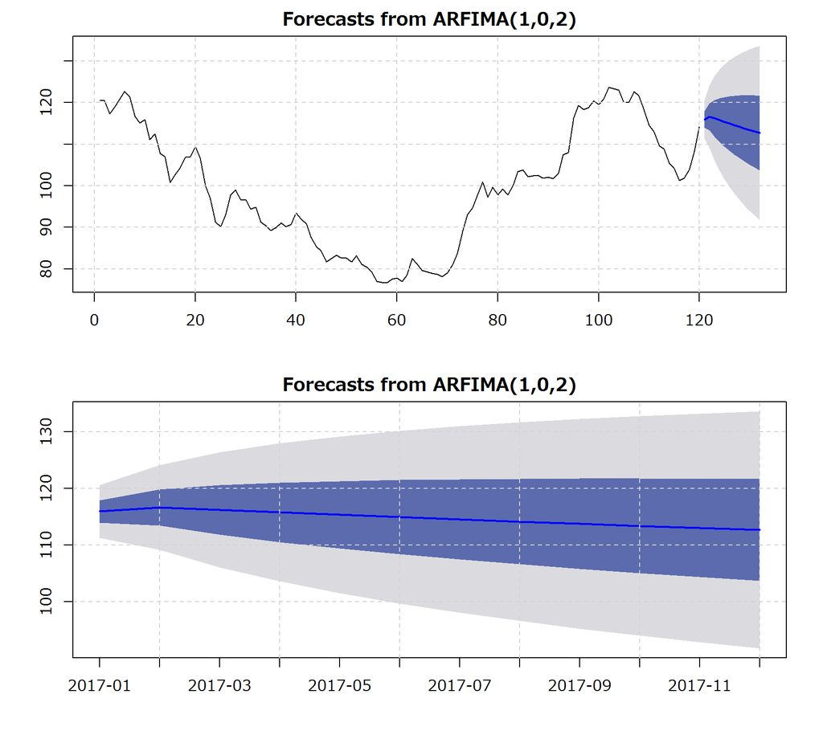

##### *C.I(%) = 60,95*

|  | Japan / U.S. Foreign Exchange Rate 2007-01~2016-12 | Latest(2016-12:114.1443) to Summary(%) | Latest(2016-12:114.1443) to Summary(Diff) |
| --- | --- | --- | --- |
| Min. | 76.64 | 148.9 | 37.5043 |
| 1st Qu. | 88.67 | 128.7 | 25.4743 |
| Median | 100.00 | 114.1 | 14.1443 |
| Mean | 99.51 | 114.7 | 14.6343 |
| 3rd Qu. | 109.90 | 103.9 | 4.2443 |
| Max. | 123.70 | 92.3 | -9.5557 |

|  | Japan / U.S. Foreign Exchange Rate lag=1,diff=1:Positive:2007-02~2016-12 | Japan / U.S. Foreign Exchange Rate lag=1,diff=1:Negative:2007-02~2016-12 |
| --- | --- | --- |
| Min. | 0.0576 | -6.6090 |
| 1st Qu. | 0.8211 | -2.8800 |
| Median | 1.6820 | -1.2440 |
| Mean | 2.0600 | -1.8690 |
| 3rd Qu. | 2.7780 | -0.7104 |
| Max. | 8.2730 | -0.0300 |

| Date | Japan / U.S. Foreign Exchange Rate lag=1,diff=1:Max&Min:2007-02~2016-12 |
| --- | --- |
| 2014-11 | 8.2730 |
| 2008-10 | -6.6089 |

|  | Japan / U.S. Foreign Exchange Rate lag=1,diff=1:2007-02~2016-12 |
| --- | --- |
| NumberPositive | 55 |
| RatioPositive | 46 |
| NumberNegative | 64 |
| RatioNegative | 54 |
| Total | 119 |

| x Straight Positive Months | N | Japan / U.S. Foreign Exchange Rate lag=1,diff=1:Ratio:2007-02~2016-12 |
| --- | --- | --- |
| 1 | 10 | 40 |
| 2 | 8 | 32 |
| 3 | 4 | 16 |
| 4 | 1 | 4 |
| 5 | 1 | 4 |
| 8 | 1 | 4 |

| x Straight Negative Months | N | Japan / U.S. Foreign Exchange Rate lag=1,diff=1:Ratio:2007-02~2016-12 |
| --- | --- | --- |
| 1 | 13 | 54.2 |
| 3 | 5 | 20.8 |
| 4 | 1 | 4.2 |
| 5 | 1 | 4.2 |
| 6 | 3 | 12.5 |
| 9 | 1 | 4.2 |

| Date | Japan / U.S. Foreign Exchange Rate n=120:2007-01~2016-12 |
| --- | --- |
| 2016-07 | 104.1910 |
| 2016-08 | 101.2383 |
| 2016-09 | 101.7843 |
| 2016-10 | 103.9075 |
| 2016-11 | 108.4430 |
| 2016-12 | 114.1443 |

| Date | Japan / U.S. Foreign Exchange Rate n=119:lag=1:diff=1:2007-02~2016-12 |
| --- | --- |
| 2016-07 | -1.1599 |
| 2016-08 | -2.9527 |
| 2016-09 | 0.5460 |
| 2016-10 | 2.1232 |
| 2016-11 | 4.5355 |
| 2016-12 | 5.7013 |

## U.S. / Euro Foreign Exchange Rate

#### Period:2007-01 ~ 2016-12

##### *“Averages of daily figures. Noon buying rates in New York City for cable transfers payable in foreign currencies.”(Source:FRED)*

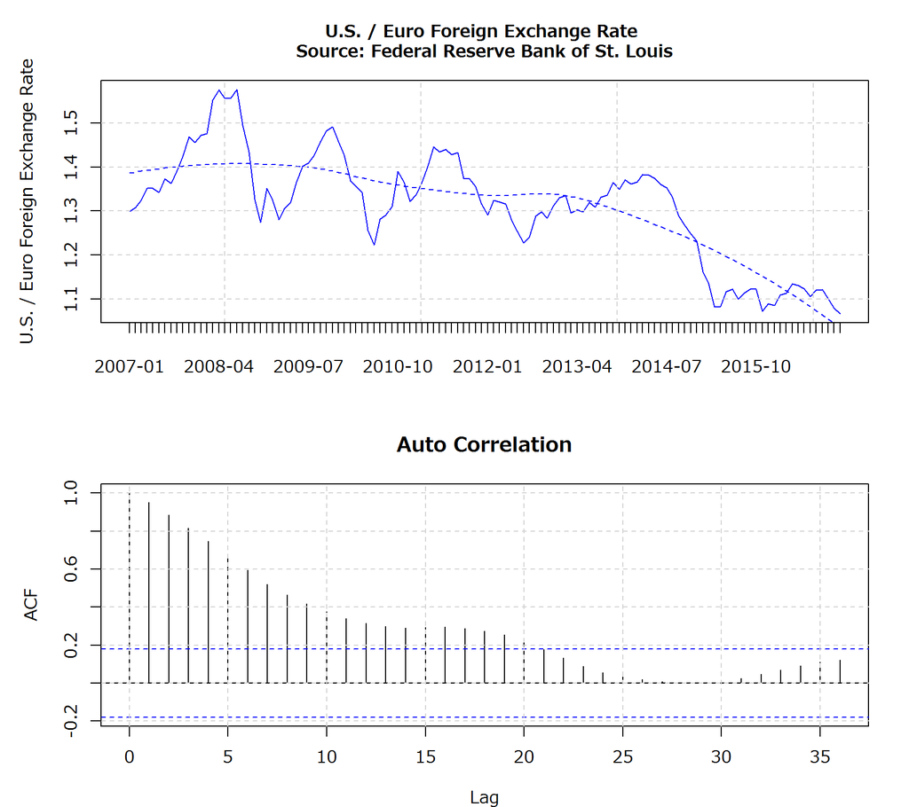

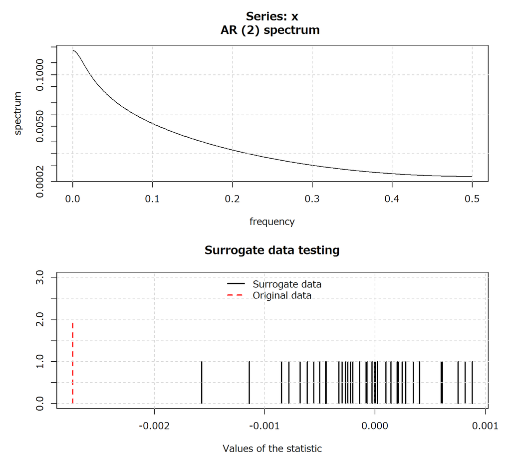

|  | Unit Root Test |
| --- | --- |
| statistic | -3.787546 |
| parameter | 4 |
| alternative | stationary |
| p.value | 0.02195792 |
| method | Augmented Dickey-Fuller Test |
| data.name | U.S. / Euro Foreign Exchange Rate |

##### Surrogate Test. Null Hypothesis: Data comes from a linear stochastic process K=1, significance=0.05

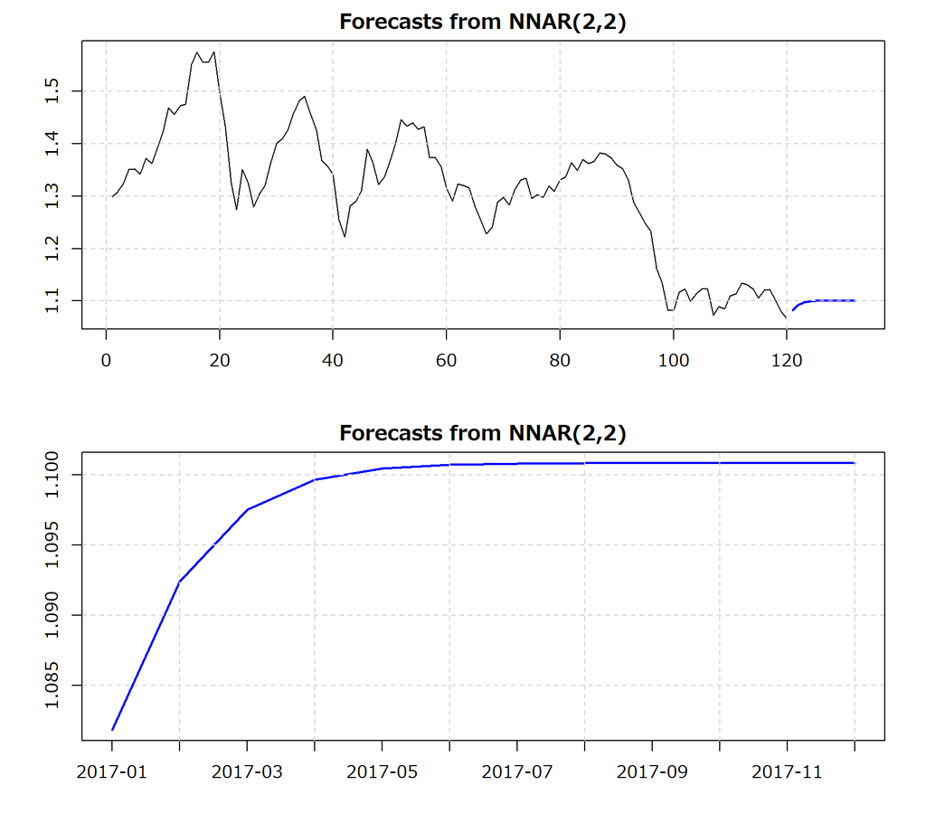

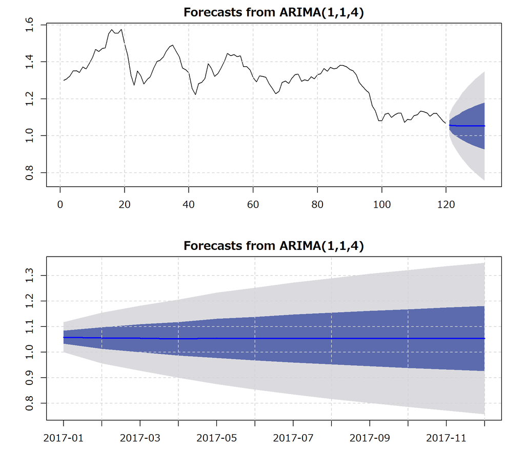

##### *C.I(%) = 60,95*

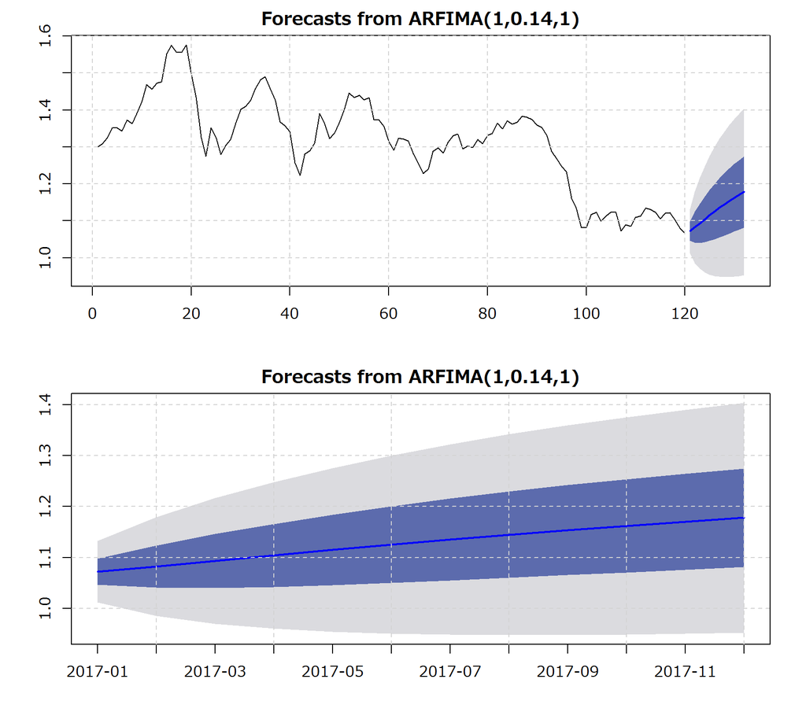

##### *C.I(%) = 60,95*

|  | U.S. / Euro Foreign Exchange Rate 2007-01~2016-12 | Latest(2016-12:1.0666) to Summary(%) | Latest(2016-12:1.0666) to Summary(Diff) |
| --- | --- | --- | --- |
| Min. | 1.067 | 100.0 | -0.0004 |
| 1st Qu. | 1.256 | 84.9 | -0.1894 |
| Median | 1.326 | 80.4 | -0.2594 |
| Mean | 1.312 | 81.3 | -0.2454 |
| 3rd Qu. | 1.376 | 77.5 | -0.3094 |
| Max. | 1.576 | 67.7 | -0.5094 |

|  | U.S. / Euro Foreign Exchange Rate lag=1,diff=1:Positive:2007-02~2016-12 | U.S. / Euro Foreign Exchange Rate lag=1,diff=1:Negative:2007-02~2016-12 |
| --- | --- | --- |
| Min. | 0.00030 | -0.10760 |
| 1st Qu. | 0.00870 | -0.03740 |
| Median | 0.01910 | -0.02040 |
| Mean | 0.02245 | -0.02677 |
| 3rd Qu. | 0.02900 | -0.01095 |
| Max. | 0.07980 | -0.00010 |

| Date | U.S. / Euro Foreign Exchange Rate lag=1,diff=1:Max&Min:2007-02~2016-12 |
| --- | --- |
| 2010-10 | 0.0798 |
| 2008-10 | -0.1076 |

|  | U.S. / Euro Foreign Exchange Rate lag=1,diff=1:2007-02~2016-12 |
| --- | --- |
| NumberPositive | 60 |
| RatioPositive | 50 |
| NumberNegative | 59 |
| RatioNegative | 50 |
| Total | 119 |

| x Straight Positive Months | N | U.S. / Euro Foreign Exchange Rate lag=1,diff=1:Ratio:2007-02~2016-12 |
| --- | --- | --- |
| 1 | 9 | 37.5 |
| 2 | 4 | 16.7 |
| 3 | 6 | 25.0 |
| 4 | 4 | 16.7 |
| 9 | 1 | 4.2 |

| x Straight Negative Months | N | U.S. / Euro Foreign Exchange Rate lag=1,diff=1:Ratio:2007-02~2016-12 |
| --- | --- | --- |
| 1 | 14 | 58.3 |
| 2 | 3 | 12.5 |
| 3 | 2 | 8.3 |
| 4 | 1 | 4.2 |
| 5 | 2 | 8.3 |
| 7 | 1 | 4.2 |
| 12 | 1 | 4.2 |

| Date | U.S. / Euro Foreign Exchange Rate n=120:2007-01~2016-12 |
| --- | --- |
| 2016-07 | 1.1055 |
| 2016-08 | 1.1207 |
| 2016-09 | 1.1218 |
| 2016-10 | 1.1014 |
| 2016-11 | 1.0792 |
| 2016-12 | 1.0666 |

| Date | U.S. / Euro Foreign Exchange Rate n=119:lag=1:diff=1:2007-02~2016-12 |
| --- | --- |
| 2016-07 | -0.0177 |
| 2016-08 | 0.0152 |
| 2016-09 | 0.0011 |
| 2016-10 | -0.0204 |
| 2016-11 | -0.0222 |
| 2016-12 | -0.0126 |

## U.S. / U.K. Foreign Exchange Rate

#### Period:2007-01 ~ 2016-12

##### *“Averages of daily figures. Noon buying rates in New York City for cable transfers payable in foreign currencies.”(Source:FRED)*

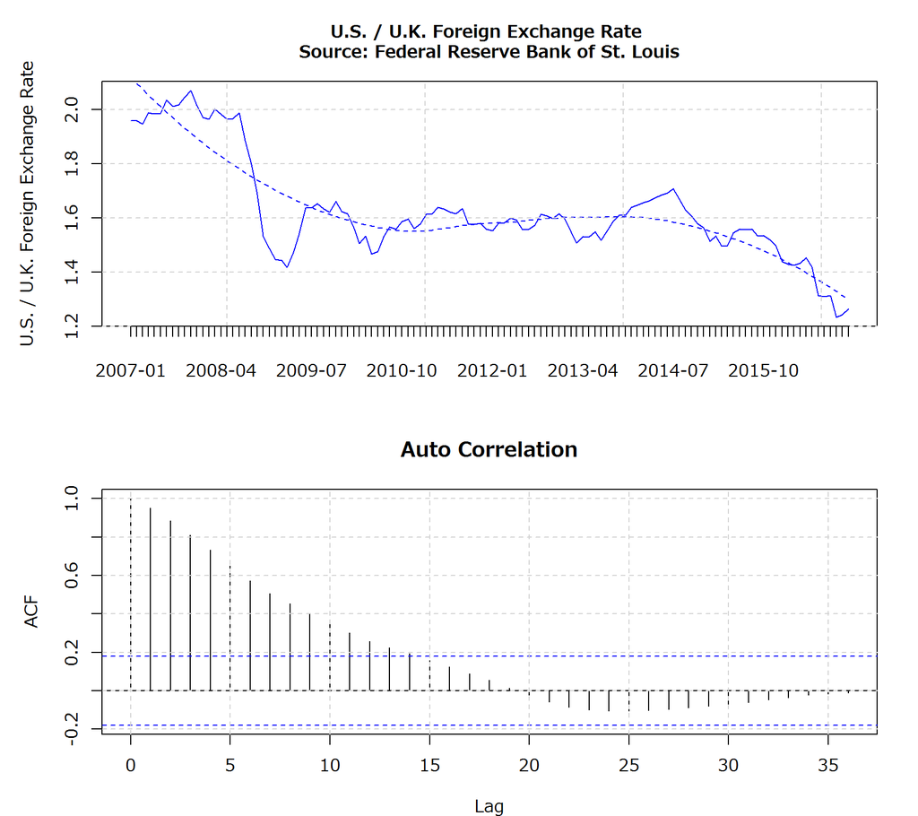

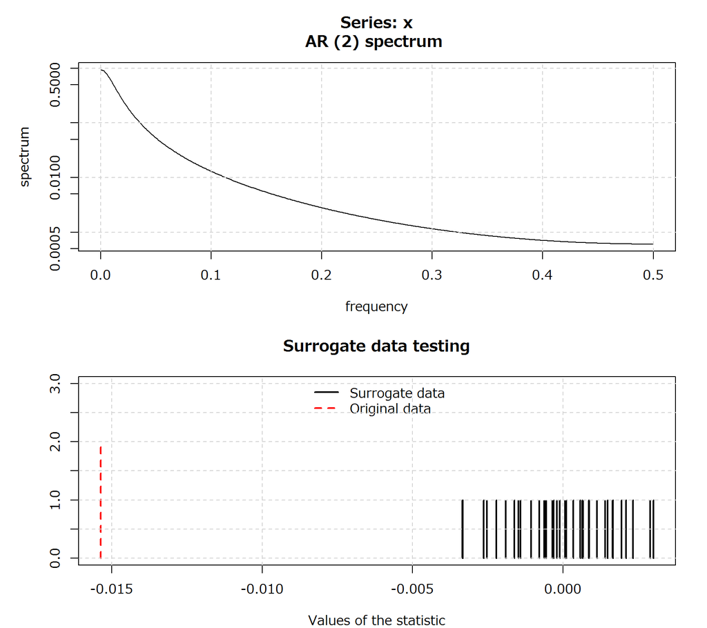

|  | Unit Root Test |
| --- | --- |
| statistic | -2.814507 |
| parameter | 4 |
| alternative | stationary |
| p.value | 0.2382867 |
| method | Augmented Dickey-Fuller Test |
| data.name | U.S. / U.K. Foreign Exchange Rate |

##### Surrogate Test. Null Hypothesis: Data comes from a linear stochastic process K=1, significance=0.05

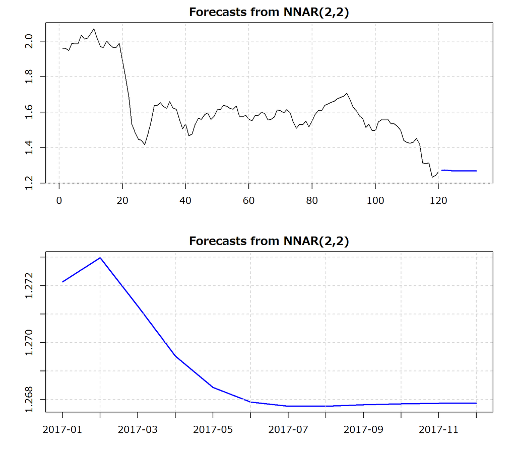

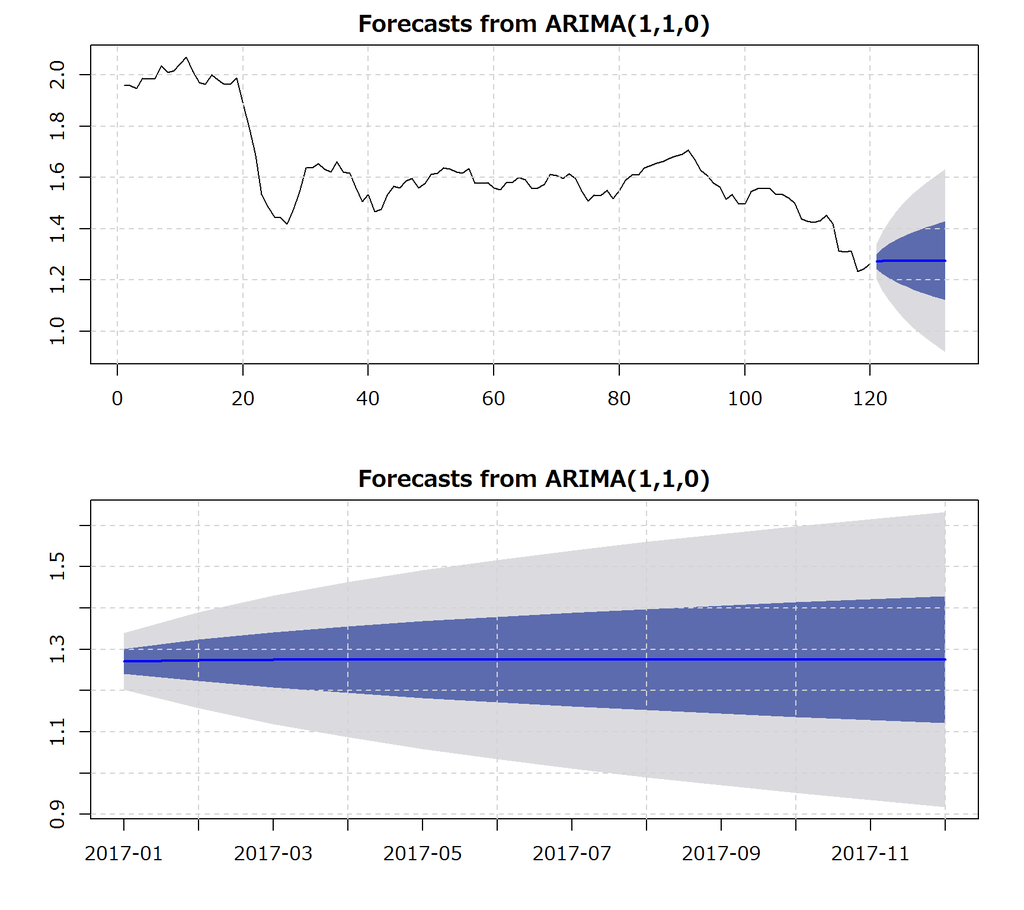

##### *C.I(%) = 60,95*

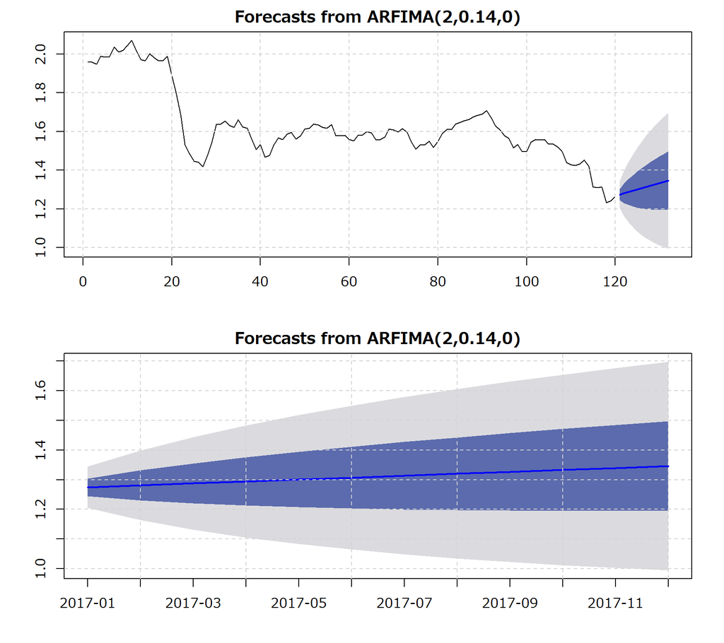

##### *C.I(%) = 60,95*

|  | U.S. / U.K. Foreign Exchange Rate 2007-01~2016-12 | Latest(2016-12:1.2638) to Summary(%) | Latest(2016-12:1.2638) to Summary(Diff) |
| --- | --- | --- | --- |
| Min. | 1.233 | 102.5 | 0.0308 |
| 1st Qu. | 1.532 | 82.5 | -0.2682 |
| Median | 1.585 | 79.7 | -0.3212 |
| Mean | 1.625 | 77.8 | -0.3612 |
| 3rd Qu. | 1.654 | 76.4 | -0.3902 |
| Max. | 2.070 | 61.1 | -0.8062 |

|  | U.S. / U.K. Foreign Exchange Rate lag=1,diff=1:Positive:2007-02~2016-12 | U.S. / U.K. Foreign Exchange Rate lag=1,diff=1:Negative:2007-02~2016-12 |
| --- | --- | --- |
| Min. | 0.00020 | -0.15350 |
| 1st Qu. | 0.00690 | -0.04660 |
| Median | 0.01820 | -0.02400 |
| Mean | 0.02085 | -0.03298 |
| 3rd Qu. | 0.02808 | -0.00890 |
| Max. | 0.09510 | -0.00030 |

| Date | U.S. / U.K. Foreign Exchange Rate lag=1,diff=1:Max&Min:2007-02~2016-12 |
| --- | --- |
| 2009-06 | 0.0951 |
| 2008-11 | -0.1535 |

|  | U.S. / U.K. Foreign Exchange Rate lag=1,diff=1:2007-02~2016-12 |
| --- | --- |
| NumberPositive | 60 |
| RatioPositive | 50 |
| NumberNegative | 59 |
| RatioNegative | 50 |
| Total | 119 |

| x Straight Positive Months | N | U.S. / U.K. Foreign Exchange Rate lag=1,diff=1:Ratio:2007-02~2016-12 |
| --- | --- | --- |
| 1 | 14 | 51.9 |
| 2 | 5 | 18.5 |
| 3 | 5 | 18.5 |
| 4 | 1 | 3.7 |
| 5 | 1 | 3.7 |
| 12 | 1 | 3.7 |

| x Straight Negative Months | N | U.S. / U.K. Foreign Exchange Rate lag=1,diff=1:Ratio:2007-02~2016-12 |
| --- | --- | --- |
| 1 | 12 | 46.2 |
| 2 | 6 | 23.1 |
| 3 | 4 | 15.4 |
| 4 | 1 | 3.8 |
| 5 | 1 | 3.8 |
| 6 | 1 | 3.8 |
| 8 | 1 | 3.8 |

| Date | U.S. / U.K. Foreign Exchange Rate n=120:2007-01~2016-12 |
| --- | --- |
| 2016-07 | 1.3134 |
| 2016-08 | 1.3101 |
| 2016-09 | 1.3140 |
| 2016-10 | 1.2330 |
| 2016-11 | 1.2432 |
| 2016-12 | 1.2638 |

| Date | U.S. / U.K. Foreign Exchange Rate n=119:lag=1:diff=1:2007-02~2016-12 |
| --- | --- |
| 2016-07 | -0.1063 |
| 2016-08 | -0.0033 |
| 2016-09 | 0.0039 |
| 2016-10 | -0.0810 |
| 2016-11 | 0.0102 |
| 2016-12 | 0.0206 |

## South Africa / U.S. Foreign Exchange Rate

#### Period:2007-01 ~ 2016-12

##### *“Averages of daily figures. Noon buying rates in New York City for cable transfers payable in foreign currencies.”(Source:FRED)*

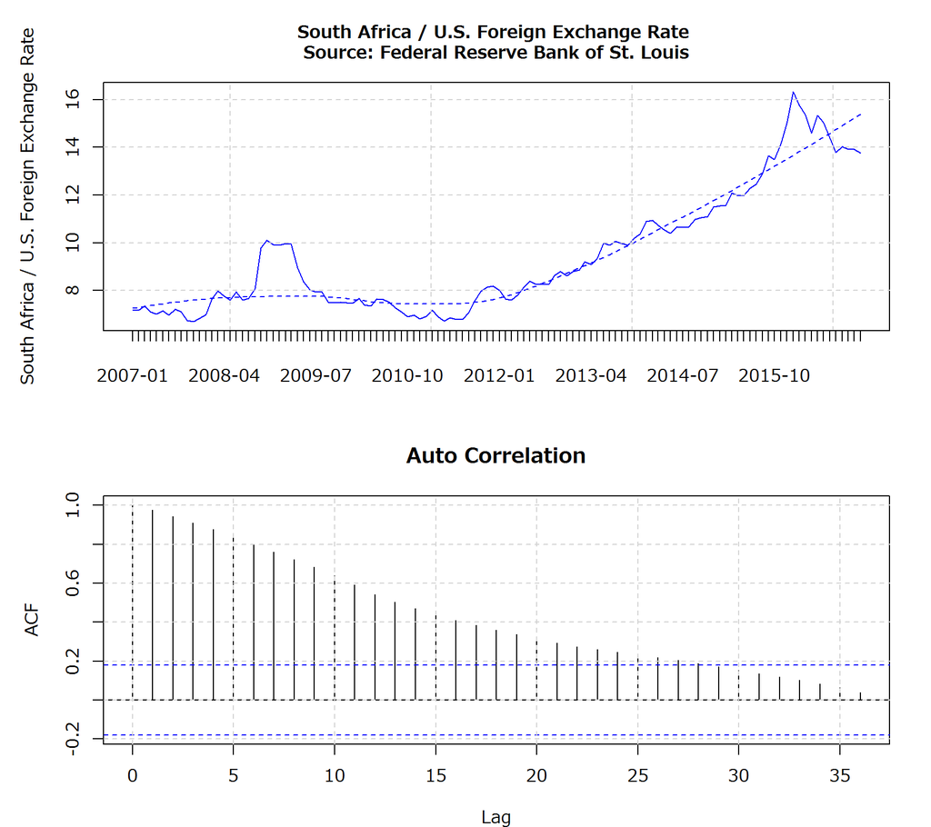

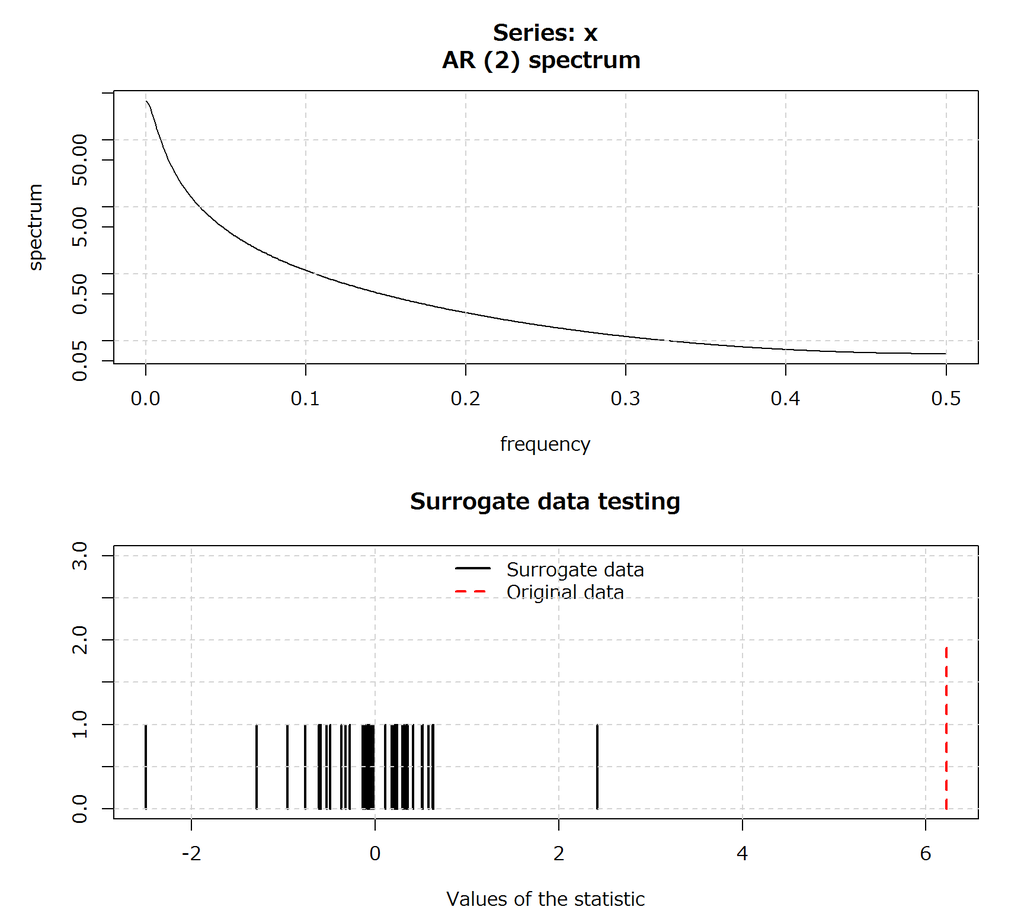

|  | Unit Root Test |
| --- | --- |
| statistic | -2.014013 |
| parameter | 4 |
| alternative | stationary |
| p.value | 0.5707524 |
| method | Augmented Dickey-Fuller Test |
| data.name | South Africa / U.S. Foreign Exchange Rate |

##### Surrogate Test. Null Hypothesis: Data comes from a linear stochastic process K=1, significance=0.05

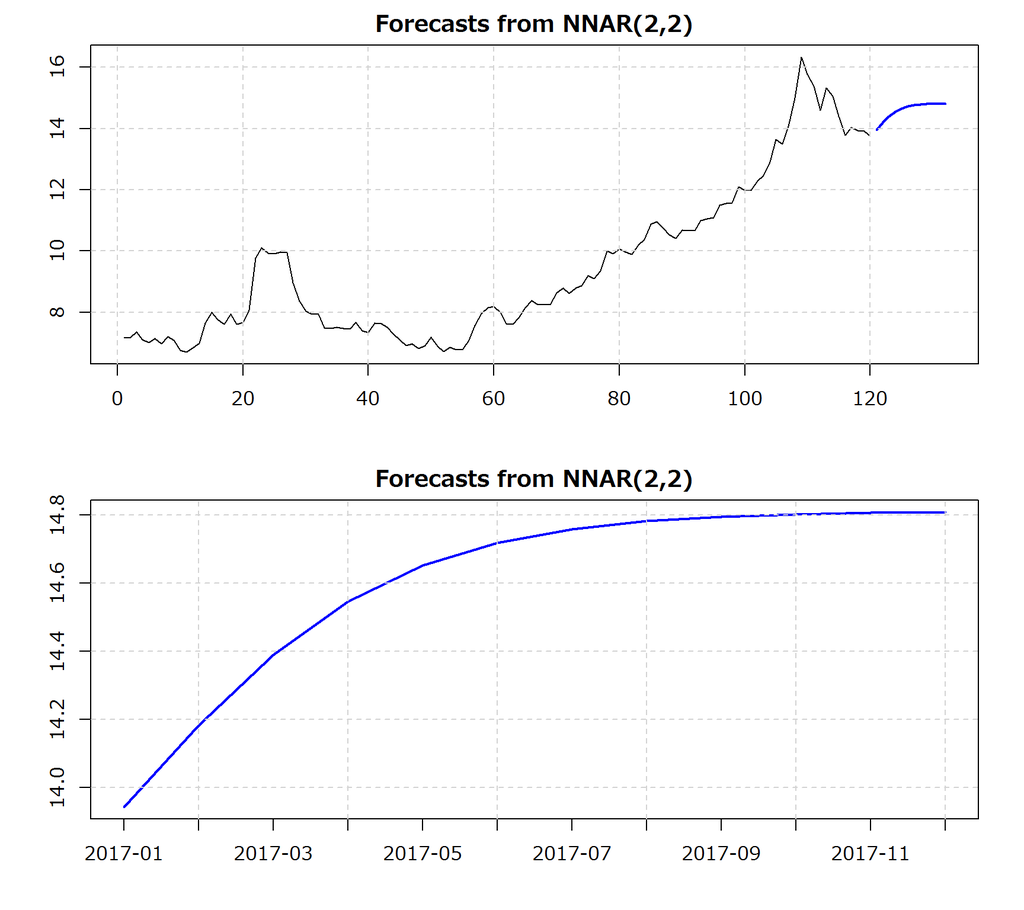

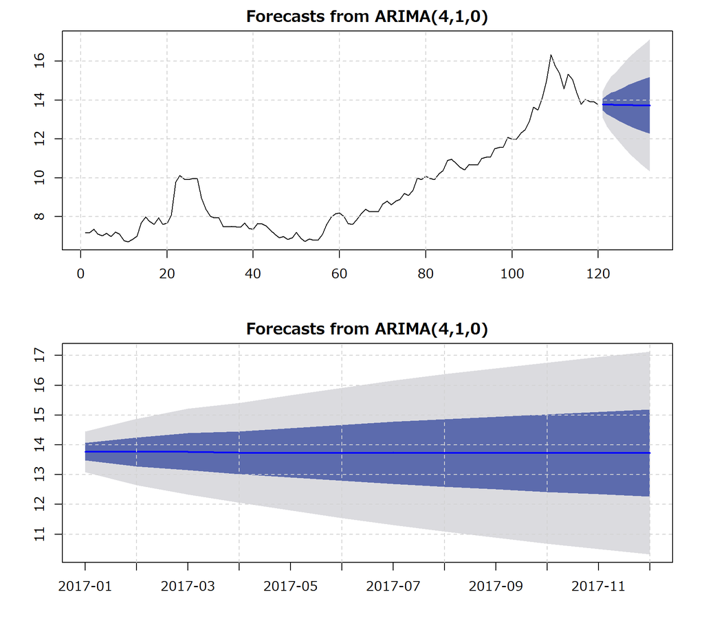

##### *C.I(%) = 60,95*

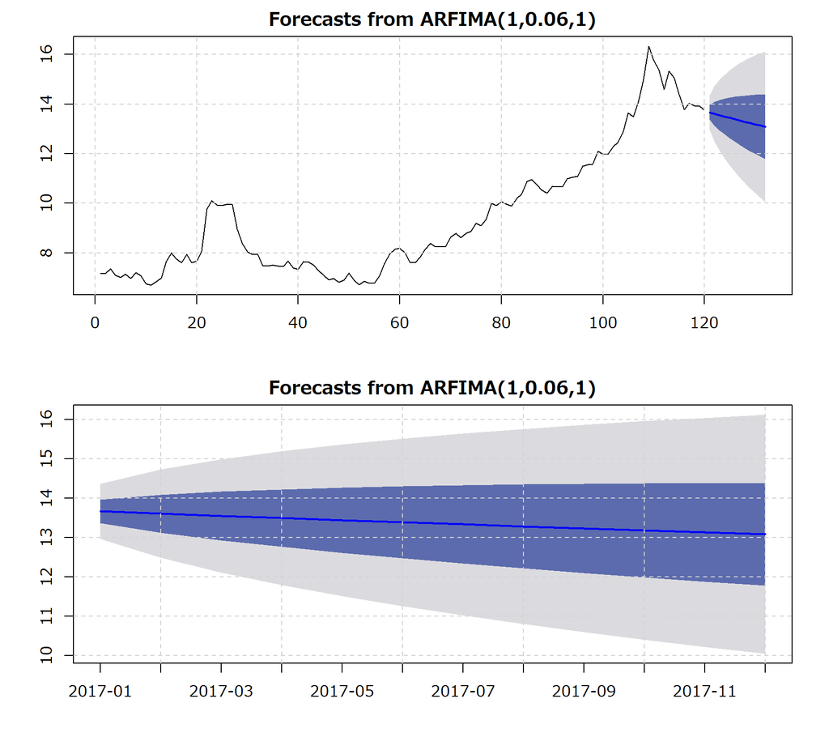

##### *C.I(%) = 60,95*

|  | South Africa / U.S. Foreign Exchange Rate 2007-01~2016-12 | Latest(2016-12:13.7518) to Summary(%) | Latest(2016-12:13.7518) to Summary(Diff) |
| --- | --- | --- | --- |
| Min. | 6.705 | 205.1 | 7.0468 |
| 1st Qu. | 7.487 | 183.7 | 6.2648 |
| Median | 8.317 | 165.3 | 5.4348 |
| Mean | 9.444 | 145.6 | 4.3078 |
| 3rd Qu. | 10.780 | 127.6 | 2.9718 |
| Max. | 16.320 | 84.3 | -2.5682 |

|  | South Africa / U.S. Foreign Exchange Rate lag=1,diff=1:Positive:2007-02~2016-12 | South Africa / U.S. Foreign Exchange Rate lag=1,diff=1:Negative:2007-02~2016-12 |
| --- | --- | --- |
| Min. | 0.0012 | -0.9892 |
| 1st Qu. | 0.1246 | -0.2561 |
| Median | 0.2430 | -0.1509 |
| Mean | 0.3073 | -0.2013 |
| 3rd Qu. | 0.3791 | -0.0625 |
| Max. | 1.7050 | -0.0022 |

| Date | South Africa / U.S. Foreign Exchange Rate lag=1,diff=1:Max&Min:2007-02~2016-12 |
| --- | --- |
| 2008-10 | 1.7047 |
| 2009-04 | -0.9892 |

|  | South Africa / U.S. Foreign Exchange Rate lag=1,diff=1:2007-02~2016-12 |
| --- | --- |
| NumberPositive | 60 |
| RatioPositive | 50 |
| NumberNegative | 59 |
| RatioNegative | 50 |
| Total | 119 |

| x Straight Positive Months | N | South Africa / U.S. Foreign Exchange Rate lag=1,diff=1:Ratio:2007-02~2016-12 |
| --- | --- | --- |
| 1 | 15 | 55.6 |
| 2 | 3 | 11.1 |
| 3 | 3 | 11.1 |
| 4 | 4 | 14.8 |
| 6 | 1 | 3.7 |
| 8 | 1 | 3.7 |

| x Straight Negative Months | N | South Africa / U.S. Foreign Exchange Rate lag=1,diff=1:Ratio:2007-02~2016-12 |
| --- | --- | --- |
| 1 | 12 | 42.9 |
| 2 | 8 | 28.6 |
| 3 | 6 | 21.4 |
| 5 | 1 | 3.6 |
| 8 | 1 | 3.6 |

| Date | South Africa / U.S. Foreign Exchange Rate n=120:2007-01~2016-12 |
| --- | --- |
| 2016-07 | 14.3930 |
| 2016-08 | 13.7828 |
| 2016-09 | 14.0264 |
| 2016-10 | 13.9273 |
| 2016-11 | 13.9125 |
| 2016-12 | 13.7518 |

| Date | South Africa / U.S. Foreign Exchange Rate n=119:lag=1:diff=1:2007-02~2016-12 |
| --- | --- |
| 2016-07 | -0.6570 |
| 2016-08 | -0.6102 |
| 2016-09 | 0.2436 |
| 2016-10 | -0.0991 |
| 2016-11 | -0.0148 |
| 2016-12 | -0.1607 |